# Ch 3: Data Visualisation Notebook

# Introduciton

## Prerequisites

```r
library("tidyverse")
```

## First Steps

```r
mpg
```

| manufacturer | model | displ | year | cyl | trans | drv | cty | hwy | fl | class |
| --- | --- | --- | --- | --- | --- | --- | --- | --- | --- | --- |
| audi | a4 | 1.8 | 1999 | 4 | auto(l5) | f | 18 | 29 | p | compact |
| audi | a4 | 1.8 | 1999 | 4 | manual(m5) | f | 21 | 29 | p | compact |
| audi | a4 | 2.0 | 2008 | 4 | manual(m6) | f | 20 | 31 | p | compact |
| audi | a4 | 2.0 | 2008 | 4 | auto(av) | f | 21 | 30 | p | compact |
| audi | a4 | 2.8 | 1999 | 6 | auto(l5) | f | 16 | 26 | p | compact |
| audi | a4 | 2.8 | 1999 | 6 | manual(m5) | f | 18 | 26 | p | compact |
| audi | a4 | 3.1 | 2008 | 6 | auto(av) | f | 18 | 27 | p | compact |
| audi | a4 quattro | 1.8 | 1999 | 4 | manual(m5) | 4 | 18 | 26 | p | compact |
| audi | a4 quattro | 1.8 | 1999 | 4 | auto(l5) | 4 | 16 | 25 | p | compact |
| audi | a4 quattro | 2.0 | 2008 | 4 | manual(m6) | 4 | 20 | 28 | p | compact |

[output cut: 224 more lines]

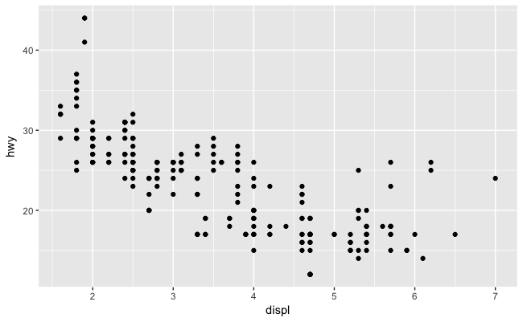

```r
ggplot(data = mpg) +
  geom_point(mapping = aes(x = displ, y = hwy))
```

### Exercises

1. Run ggplot(data = mpg) what do you see?

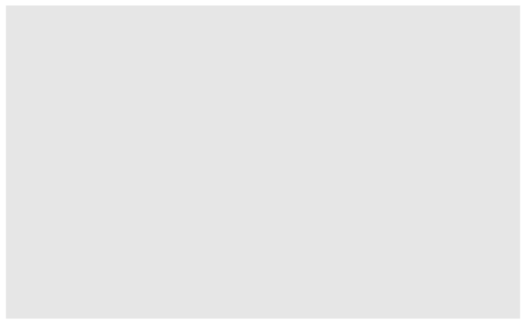

```r
ggplot(data = mpg)
```

2. How many rows are in `mtcars`? How many columns?

```r
nrow(mtcars)
ncol(mtcars)
```

[output not shown]

This can also be found by printing the dataset, or looking in the environment pane.

3. What does the drv variable describe? Read the help for `?mpg` to find out.

```r
?mpg
```

The `drv` variable takes the following values

- f = front-wheel drive
- r = rear wheel drive
- 4 = 4wd
4. Make a scatterplot of `hwy` vs `cyl`

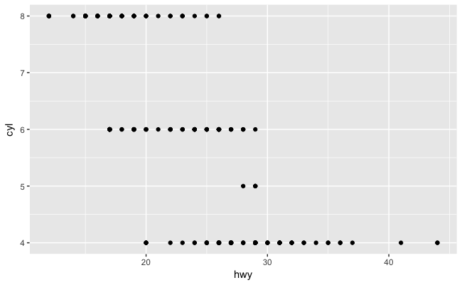

```r
ggplot(mpg, aes(x = hwy, y = cyl)) +
  geom_point()
```

5. What happens if you make a scatterplot of `class` vs `drv`. Why is the plot not useful?

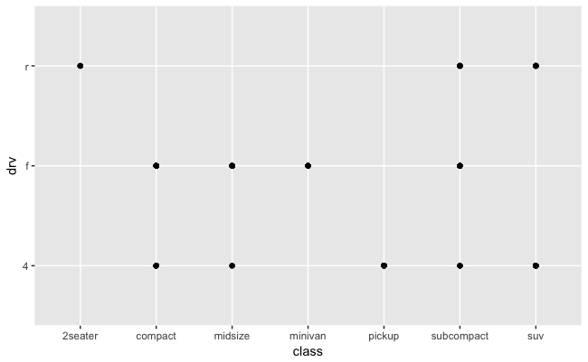

```r
ggplot(mpg, aes(x = class, y = drv)) +
  geom_point()
```

A scatterplot is not a useful way to plot these variables, since both `drv` and `class` are factor variables, and the scatterplot cannot show which are overlapping or not.

```r
count(mpg, drv, class)
```

| drv | class | n |
| --- | --- | --- |
| 4 | compact | 12 |
| 4 | midsize | 3 |
| 4 | pickup | 33 |
| 4 | subcompact | 4 |
| 4 | suv | 51 |
| f | compact | 35 |
| f | midsize | 38 |
| f | minivan | 11 |
| f | subcompact | 22 |
| r | 2seater | 5 |

[output cut: 2 more lines]

## Aesthetic mappings

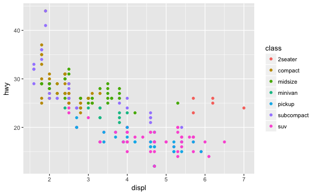

```r
ggplot(data = mpg) +
  geom_point(mapping = aes(x = displ, y = hwy, colour = class))
```

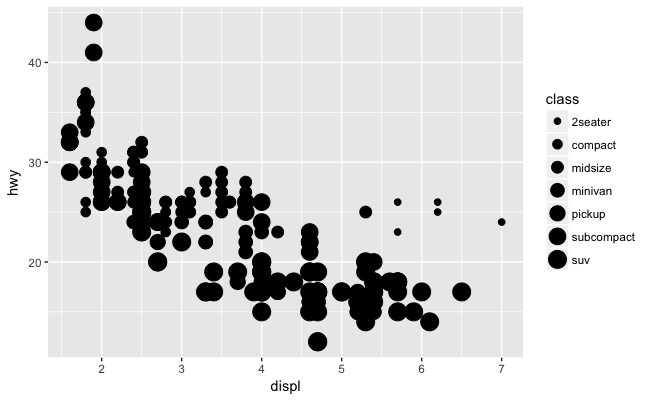

```r
ggplot(data = mpg) +
  geom_point(mapping = aes(x = displ, y = hwy, size = class))
```

```r
NA
```

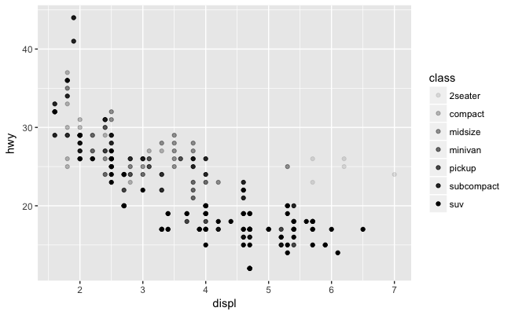

```r
ggplot(data = mpg) +
  geom_point(mapping = aes(x = displ, y = hwy, alpha = class))
```

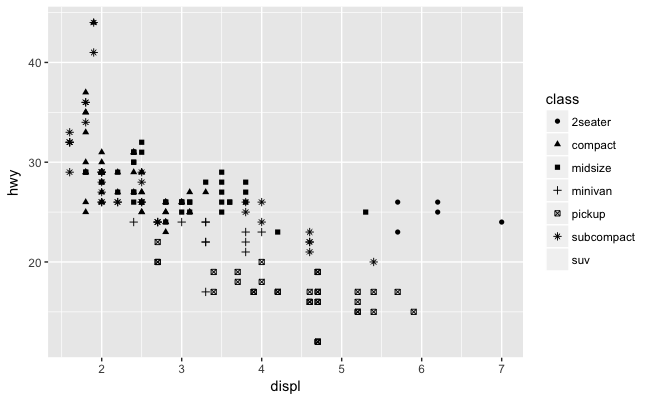

```r
ggplot(data = mpg) +
  geom_point(mapping = aes(x = displ, y = hwy, shape = class))
```

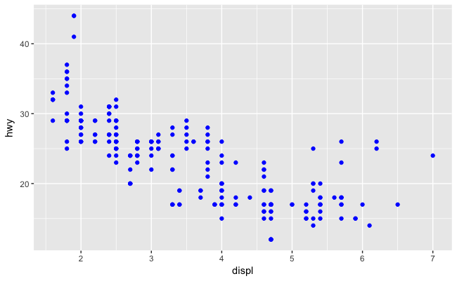

```r
ggplot(data = mpg) +
  geom_point(mapping = aes(x = displ, y = hwy), color = "blue")
```

### Exercises

1. What’s gone wrong with this code? Why are the points not blue?

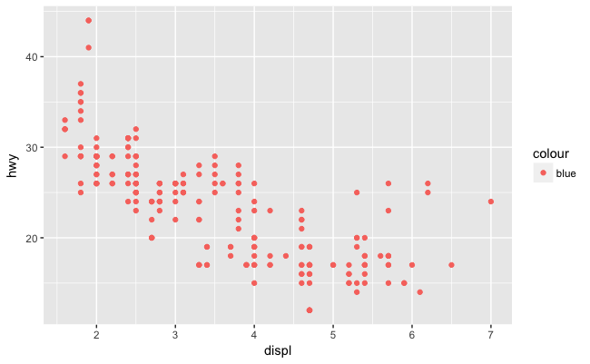

```r
ggplot(data = mpg) +
  geom_point(mapping = aes(x = displ, y = hwy, color = "blue"))
```

Since `color = "blue"` was included within the `mapping` argument, it was treated as an aesthetic (a mapping between a variable and a value). It was treated as a variable which has only one value: “blue”.

2. Which variables in mpg are categorical? Which variables are continuous? (Hint: type ?mpg to read the documentation for the dataset). How can you see this information when you run mpg?

```r
?mpg
```

When printing the data frame, this information is given at the top of each column within angled brackets. Categorical variables have a class of “character” (`<chr>`).

```r
mpg
```

| manufacturer | model | displ | year | cyl | trans | drv | cty | hwy | fl | class |
| --- | --- | --- | --- | --- | --- | --- | --- | --- | --- | --- |
| audi | a4 | 1.8 | 1999 | 4 | auto(l5) | f | 18 | 29 | p | compact |
| audi | a4 | 1.8 | 1999 | 4 | manual(m5) | f | 21 | 29 | p | compact |
| audi | a4 | 2.0 | 2008 | 4 | manual(m6) | f | 20 | 31 | p | compact |
| audi | a4 | 2.0 | 2008 | 4 | auto(av) | f | 21 | 30 | p | compact |
| audi | a4 | 2.8 | 1999 | 6 | auto(l5) | f | 16 | 26 | p | compact |
| audi | a4 | 2.8 | 1999 | 6 | manual(m5) | f | 18 | 26 | p | compact |
| audi | a4 | 3.1 | 2008 | 6 | auto(av) | f | 18 | 27 | p | compact |
| audi | a4 quattro | 1.8 | 1999 | 4 | manual(m5) | 4 | 18 | 26 | p | compact |
| audi | a4 quattro | 1.8 | 1999 | 4 | auto(l5) | 4 | 16 | 25 | p | compact |
| audi | a4 quattro | 2.0 | 2008 | 4 | manual(m6) | 4 | 20 | 28 | p | compact |

[output cut: 224 more lines]

The `glimpse` command from “mpg” shows this:

```r
glimpse(mpg)
```

```
Observations: 234
Variables: 11
$ manufacturer <chr> "audi", "audi", "audi", "audi", "a...
$ model        <chr> "a4", "a4", "a4", "a4", "a4", "a4"...
$ displ        <dbl> 1.8, 1.8, 2.0, 2.0, 2.8, 2.8, 3.1,...
$ year         <int> 1999, 1999, 2008, 2008, 1999, 1999...
$ cyl          <int> 4, 4, 4, 4, 6, 6, 6, 4, 4, 4, 4, 6...
$ trans        <chr> "auto(l5)", "manual(m5)", "manual(...
$ drv          <chr> "f", "f", "f", "f", "f", "f", "f",...
$ cty          <int> 18, 21, 20, 21, 16, 18, 18, 18, 16...
$ hwy          <int> 29, 29, 31, 30, 26, 26, 27, 26, 25...
$ fl           <chr> "p", "p", "p", "p", "p", "p", "p",...
$ class        <chr> "compact", "compact", "compact", "...
```

3. Map a continuous variable to color, size, and shape. How do these aesthetics behave differently for categorical vs. continuous variables?

The variable `cty`, city highway miles per gallon, is a continuous variable:

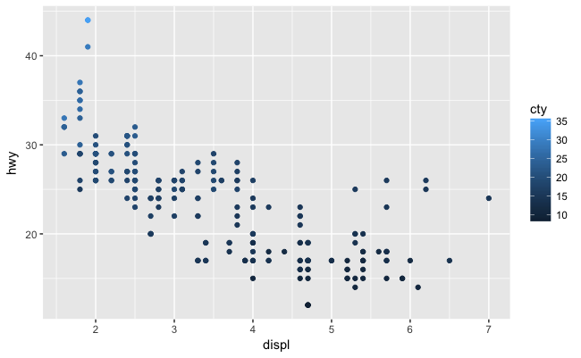

```r
ggplot(mpg, aes(x = displ, y = hwy, color = cty)) +
  geom_point()
```

Instead of using discrete colors, the continous variable uses a scale that goes from black to bluish.

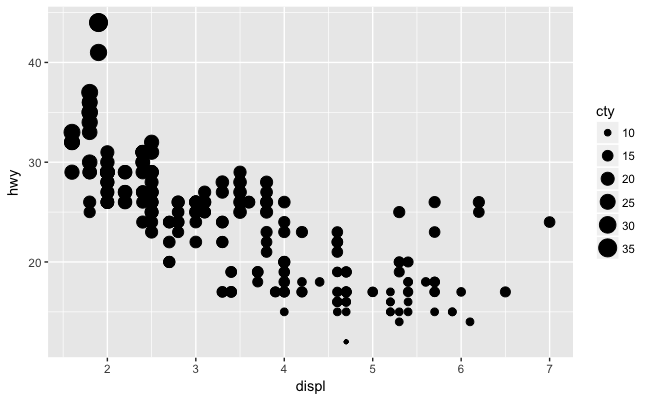

```r
ggplot(mpg, aes(x = displ, y = hwy, size = cty)) +
  geom_point()
```

When mapped to size, the sizes of the points vary continuously with respect to the size (although the legend shows a few representative values)

```r
ggplot(mpg, aes(x = displ, y = hwy, shape = cty)) +
  geom_point()
```

```
Error: A continuous variable can not be mapped to shape
```

When a continuous value is mapped to shape, it gives an error. Though we could split a continuous variable into discrete categories and use shape, this would conceptually not make sense. A continuous numeric variable is ordered, but shapes have no natural order. It is clear that smaller points correspond to smaller values, or once the color scale is given, which points are larger or smaller. But it is not clear whether a square is greater or less than a circle.

4. What happens if you map the same variable to multiple aesthetics?

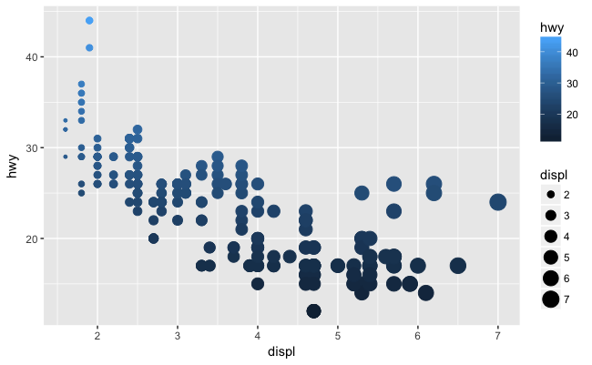

```r
ggplot(mpg, aes(x = displ, y = hwy, color = hwy, size = displ)) +
  geom_point()
```

In the above plot, `hwy` is mapped to both location on the y-axis and color, and `displ` is mapped to both location on the x-axis and size. The code works and produces a plot, even if it is a bad one. Mapping a single variable to multiple aesthetics is redundant. Because it is redundant information, in most cases avoid mapping a single variable to multiple aesthetics.

5. What does the stroke aesthetic do? What shapes does it work with? (Hint: use `?geom_point`)

The following example is given in `?geom_point`:

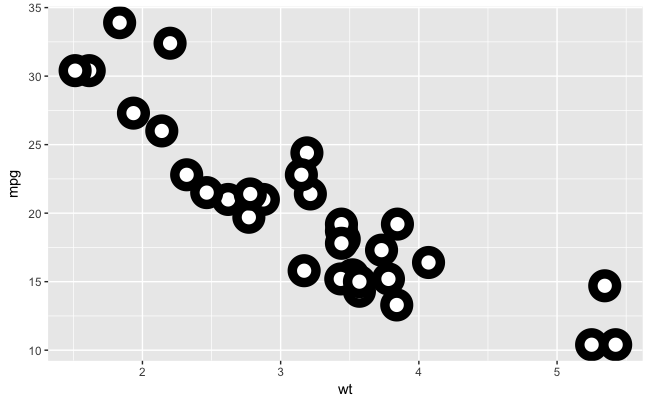

```r
ggplot(mtcars, aes(wt, mpg)) +
  geom_point(shape = 21, colour = "black", fill = "white", size = 5, stroke = 5)
```

6. What happens if you map an aesthetic to something other than a variable name, like `aes(colour = displ < 5)`?

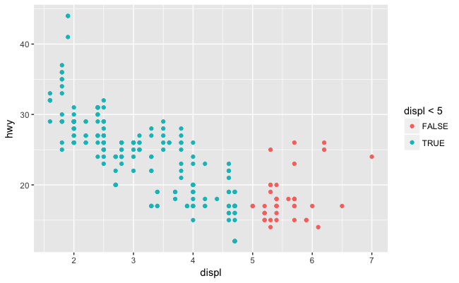

```r
ggplot(mpg, aes(x = displ, y = hwy, colour = displ < 5)) +
  geom_point()
```

Aesthetics can also be mapped to expressions (code like `displ < 5`). It will create a temporary variable which takes values from the result of the expression. In this case, it is logical variable which is `TRUE` or `FALSE`. This also explains exercise 1, `color = "blue"` created a categorical variable that only had one category: “blue”.

## Facets

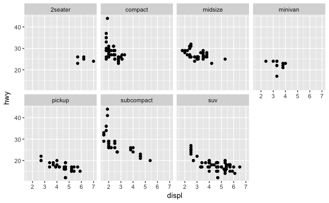

```r
ggplot(data = mpg)+
  geom_point(mapping = aes(x = displ, y = hwy)) +
  facet_wrap(~ class, nrow = 2)
```

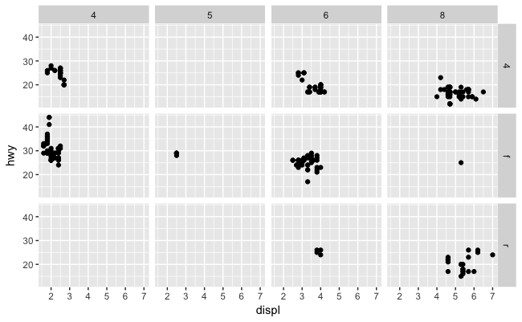

```r
ggplot(dat = mpg) +
  geom_point(mapping = aes(x = displ, y = hwy)) +
  facet_grid(drv ~ cyl)
```

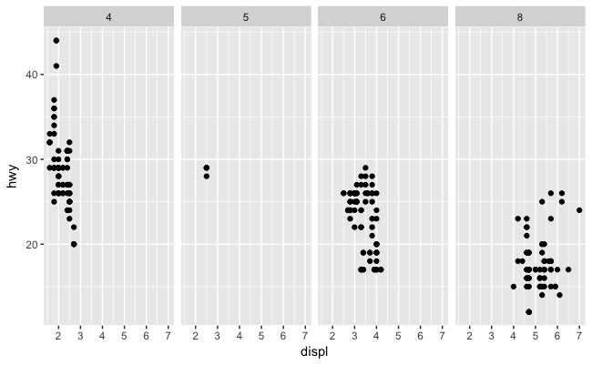

```r
ggplot(data = mpg) +
  geom_point(mapping = aes(x = displ, y = hwy)) +
  facet_grid(. ~ cyl)
```

The expression `. ~ cyl` only facets by the variable `cyl` on the x axis. Likewise, the expression `cyl ~ .` only factets by `cyl` on the y-axis.

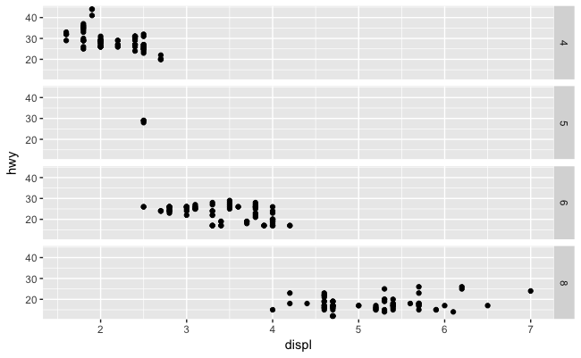

```r
ggplot(data = mpg) +
  geom_point(mapping
              = aes(x = displ, y = hwy)) +
  facet_grid(cyl ~ .)
```

## Facets

### Exercises

1. What happens if you facet on a continuous variable?

Let’s see

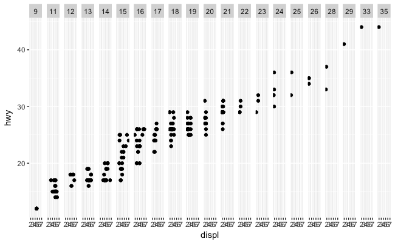

```r
ggplot(mpg, aes(x = displ, y = hwy)) +
  geom_point() +
  facet_grid(. ~ cty)
```

It converts the continuous varible to a factor and creates facets for **all** unique values of it.

2. What do the empty cells in plot with `facet_grid(drv ~ cyl)` mean? How do they relate to this plot?

They are cells in which there are no values of the combination of `drv` and `cyl`.

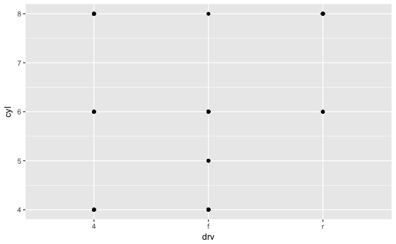

```r
ggplot(data = mpg) +
  geom_point(mapping = aes(x = drv, y = cyl))
```

The locations in the above plot without points are the same cells in `facet_grid(drv ~ cyl)` tha have no points.

3. What plots does the following code make? What does `.` do?

The symbol `.` ignores that dimension for faceting.

This plot facets by values of `drv` on the y-axis:

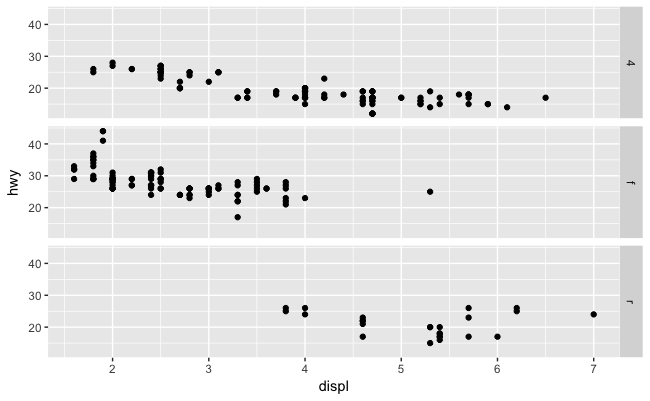

```r
ggplot(data = mpg) +
  geom_point(mapping = aes(x = displ, y = hwy)) +
  facet_grid(drv ~ .)
```

This plot facets by values of `cyl` on the x-axis:

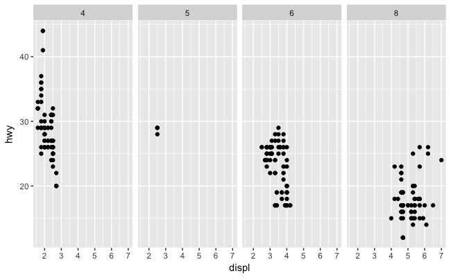

```r
ggplot(data = mpg) +
  geom_point(mapping = aes(x = displ, y = hwy)) +
  facet_grid(. ~ cyl)
```

5. Read `?facet_wrap`. What does `nrow` do? What does `ncol` do? What other options control the layout of the individual panels? Why doesn’t `facet_grid()` have `nrow` and `ncol` variables?

The arguments `nrow` (`ncol`) determines the number of rows (columns) to use when laying out the facets. It is necessary since `facet_wrap` only facets on one variable. These arguments are unnecessary for `facet_grid` since the number of rows and columns are determined by the number of unique values of the variables specified.

6. When using `facet_grid()` you should usually put the variable with more unique levels in the columns. Why?

You should put the variable with more unique levels in the columns if the plot is laid out landscape. It is easier to compare relative levels of y by scanning horizontally, so it may be easier to visually compare these levels. *I’m actually not sure about the correct answer to this*.